# QMSS5069 - Advanced Data Science Final Project: Predicting Housing Prices

Lizhizi Cui (lc3268) and Mario Saraiva (mhs2195)

May 2018

`Applied Data Science for Social Sciences Project: Preliminary results`

`Lizhizi Cui (lc3268) and Mario Saraiva (mhs2195)`

`March 28, 2018`

## Introduction

In this consulting project, our main goal is to advise our client on where is the best neighborhood to buy a house and how much a house he likes may cost. Our client, a professor at the Utah State University, approached our team seeking for advice on where he should buy his next house in hopes to sell it in a couple of years and profit out of the transaction. The professor has a strict preference for houses within the city of Ames, IA and he is not interested buying anywhere else. The client has a price preference for houses between $180,000 - 210,000.

To best attend to our client’s request, we explored the housing data on Ames, IA through different visualizations and a correlation plot to understand the dataset [^1]. Then different inference models were constructed to verify our hypothesis. Once the hypothesis had been tested we proceeded to the predictive modeling section, where through various machine learning models we predict the final sales price of a house. The last section of this document presents our conclusions and recommendations.

## 1. Housing Data

The dataset contains information on 1460 houses in Ames, Iowa. There are 81 variables in total, of which 37 are quantitative including the final Sales Price of the house, 43 are categorical + the Id number of each house. For more additional details on the available variables please refer to the annex section.

### 1.1 Missing values

`Table 1: Missing Data`

| Variable | # of Nas |
| --- | --- |
| PoolQC | 1453 |
| MiscFeature | 1406 |
| Alley | 1369 |
| Fence | 1179 |
| FireplaceQu | 690 |
| LotFrontage | 259 |
| GarageType | 81 |
| GarageYrBlt | 81 |
| GarageFinish | 81 |
| GarageQual | 81 |
| GarageCond | 81 |
| BsmtExposure | 38 |
| BsmtFinType2 | 38 |
| BsmtQual | 37 |
| BsmtCond | 37 |
| BsmtFinType1 | 37 |
| MasVnrType | 8 |
| MasVnrArea | 8 |
| Electrical | 1 |

### 1.2 Dealing with missing values

We assessed the missing values and identified the ones that were not missing at random. These were modified separately and then a new dataset containing 1451 observations and 79 variables was created. More details of how we perform data wrangling and deal with missing values are shown in the rmd file.

## 2. Inference

### 2.1 Hypothesis

Our initial hypothesis is that there is a positive association between the final sales price and distance from ISU. In other words, houses that are further away from the university are, in general, sold for a higher price than those in neighborhoods closer to ISU. Without doing any data analysis, we know that there is a golf course at the opposite end of the city from the University, which could be evidence supporting our hypothesis. Additionally, student housing usually has a lower price in comparison with other non-student houses, if this is true in Ames, then our hypothesis should be correct.

**Hypothesis:**

$$Sales Price = \beta_0 + \beta_{Dist. ISU} + \beta_{House Quality} + \beta_{Size} + ... + \mu$$
*Where $\beta_{Dist. ISU}$ is positive.

### 2.2 Context

Ames, IA located in the midwest of the United States is predominantly a college city. Ames has a population of 62,815 people with a median age of 23.2. The city is home for the Iowa State University (ISU) and its 35,000 students (excluding postdoc students and faculty members). Not surprisingly, the city has a median household income of $41,616.

According to Data USA, the median property value in Ames, IA is $174,300, and the homeownership rate is 41%. The average commute time is 15.7 minutes. The average car ownership in Ames, IA is 2 cars per household. [^2]

From the data, we can see that three neighborhoods - NoRidge, NridgHt, and StoneBr - have the highest average sales price, $300,000 or more. We classified these three neighborhoods as “High”, in regards to their average sales price. Similarly, we identified two other strata of neighborhoods one as “Medium” with the average sales price between $150,000 and $300,000, and “Low” all neighborhoods with average sales price up to $150,000.

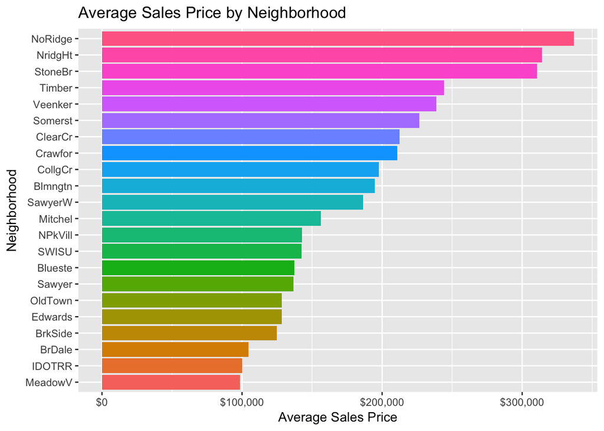

`Figure 1.1 summarizes the the average sales price for each neighborhood in Ames, Iowa.`

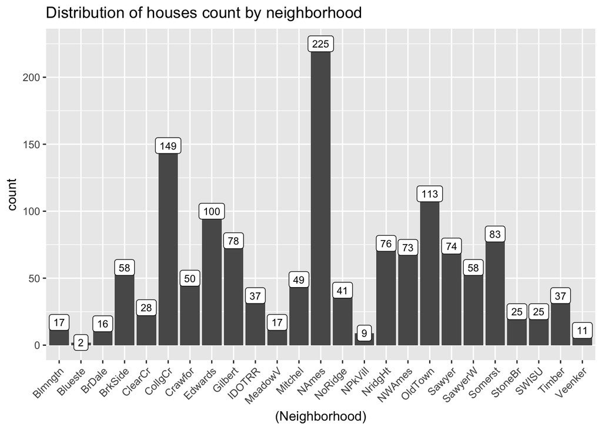

|  | Lower | Median | Higher |
| --- | --- | --- | --- |
| **Blmngtn** | 12 | 5 | 0 |
| **Blueste** | 2 | 0 | 0 |
| **BrDale** | 16 | 0 | 0 |
| **BrkSide** | 53 | 5 | 0 |
| **ClearCr** | 14 | 12 | 2 |
| **CollgCr** | 79 | 66 | 4 |
| **Crawfor** | 24 | 20 | 6 |
| **Edwards** | 95 | 4 | 1 |
| **IDOTRR** | 37 | 0 | 0 |
| **MeadowV** | 17 | 0 | 0 |
| **Mitchel** | 43 | 6 | 0 |
| **NoRidge** | 1 | 18 | 21 |
| **NPkVill** | 9 | 0 | 0 |
| **NridgHt** | 7 | 28 | 41 |
| **OldTown** | 108 | 3 | 2 |
| **Sawyer** | 74 | 0 | 0 |
| **SawyerW** | 37 | 18 | 3 |
| **Somerst** | 31 | 42 | 10 |
| **StoneBr** | 4 | 10 | 11 |
| **SWISU** | 25 | 0 | 0 |
| **Timber** | 11 | 18 | 8 |
| **Veenker** | 5 | 4 | 2 |

`Table 2: Number of houses by price category and neighborhood`

### 2.3 Hypothesis

As seen in the ‘Context’ section, the city of Ames is a college city, with approximately 35,993 students (excluding postdocs), accounting for more than 57% of the population. This is a conservative estimate since we are not including the university’s staff. Arguably, at least 60% of Ames works and/or studies at the Iowa State University.

`Then, what is the relationship between the distance from the university and the final sales price of a house?`

Our dataset does not have the exact location of each house, so we used the average distance between the approximate center point of each neighborhood to the center of IUS campus. We used google maps to calculate the distance in miles by car and walking, as well as, the time it would take to go from the location to the IUS campus. Since the campus is fairly large we used Global Café, 513 Farm House Ln, Ames, IA, 50010, as our reference point representing the University. See annex for a full description of our distance variables.

### 2.4 Understanding key variables

#### **SalePrice**

SalePrice: the property’s sale price in dollars

```
##    Min. 1st Qu.  Median    Mean 3rd Qu.    Max.
##   34900  129900  162500  180624  214000  755000
```

```
## [1] 34.9
```

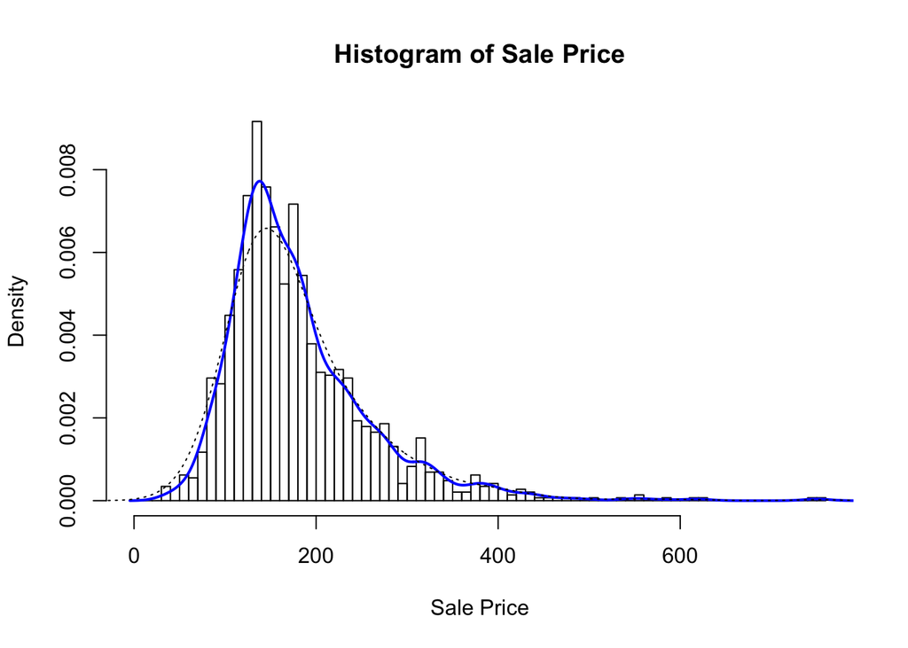

`Figure 2.1 summarizes the frequency of Sales Price for all houses.`

#### **Overall Quality**

OverallQual: Rates the overall material and finish of the house

```
   10   Very Excellent
   9    Excellent
   8    Very Good
   7    Good
   6    Above Average
   5    Average
   4    Below Average
   3    Fair
   2    Poor
   1    Very Poor
```

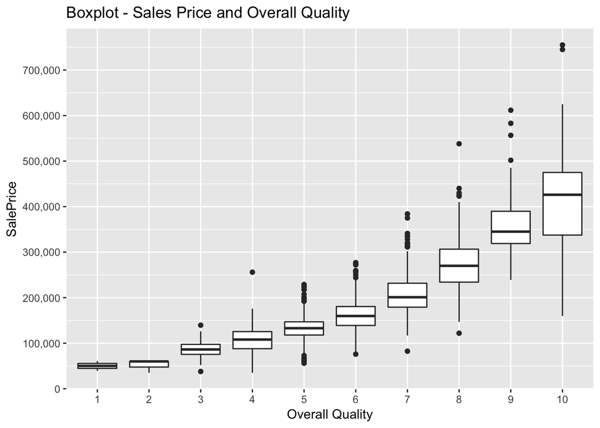

`Figure 2.2 summarizes the relationship of Sales Price and Overall Quality Rating of houses.`

#### **OverallCond**

OverallCond: Rates the overall condition of the house:

```
   10   Very Excellent
   9    Excellent
   8    Very Good
   7    Good
   6    Above Average
   5    Average
   4    Below Average
   3    Fair
   2    Poor
   1    Very Poor
```

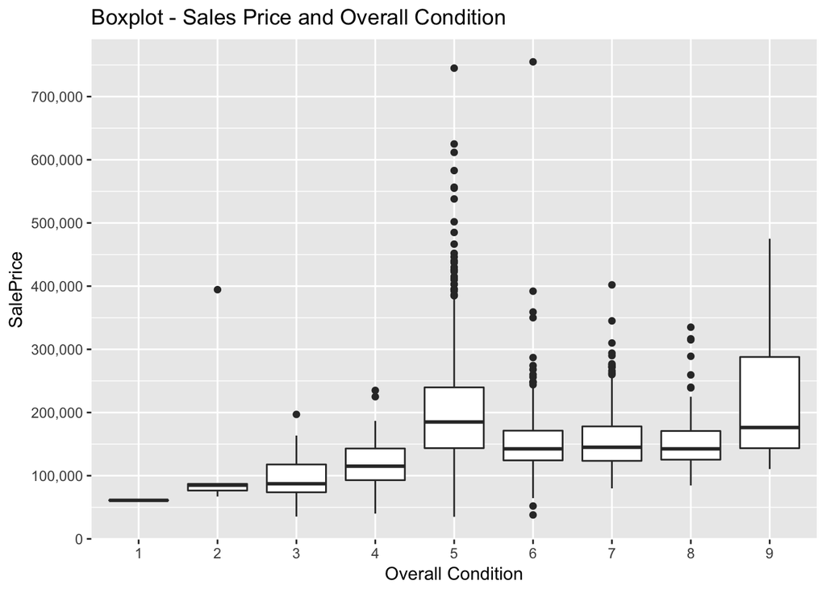

`Figure 2.3 summarizes the relationship of Sales Price and Overall Condition Rating of houses.`

#### **‘GrLivArea’ (Above Ground Living Area)**

GrLivArea: Above ground living area square feet  
GrLivArea is observed to have a positive correlation with SalePrice, which make sense since big houses are generally more expensive than smaller. One thing worth noticing is that there are two houses with really large living areas and low SalePrice (potential to be outliers). I checked the data and found out they are houses 524, 1299 and 2550(NA for SalePrice).

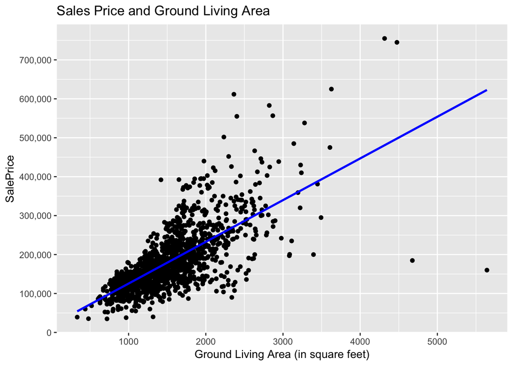

`Figure 2.4 summarizes the relationship of Sales Price and Ground Living Area of houses.`

[output not shown]

#### **GarageCars**

The Size of garage shows a positive correlation with SalePrice from level 0-3 but fall at level 4 (non-linear correlation). It makes sense because only big houses have a large garage, and bigger houses usually have higher SalePrice. Also for houses with a 3 cars garage (level 3), there are several outliners with much higher SalePrice existing, it must be other factors affecting the outcome price. Something might happen for houses with level 4 garage that needed to be explained.

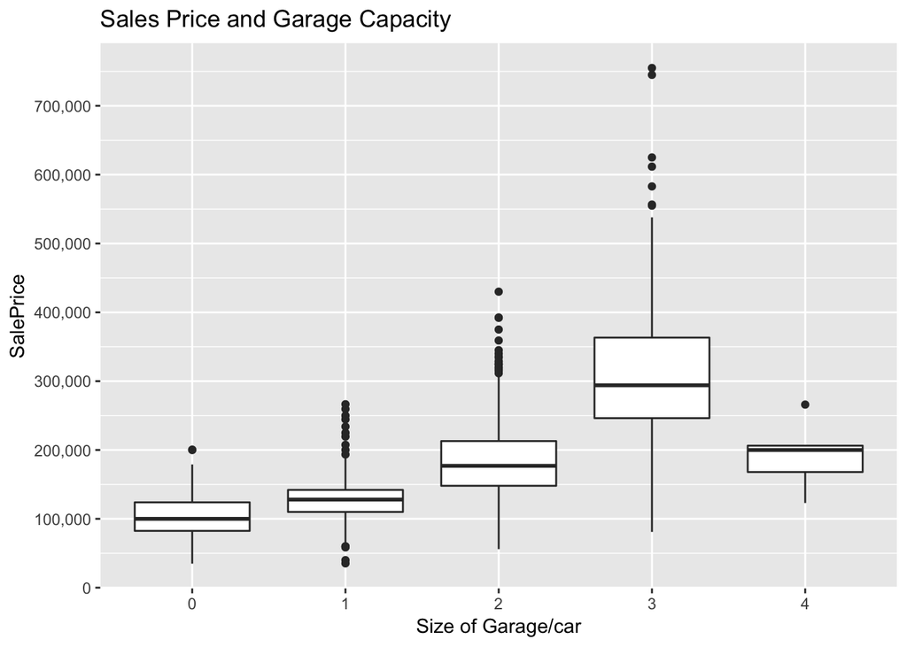

[output not shown]

`Figure 2.5 summarizes the relationship of Sales Price and Capacity of Garage of houses.`

#### **BsmtFinSF1**

BsmtFinSF1: Type 1 basement finished square feet

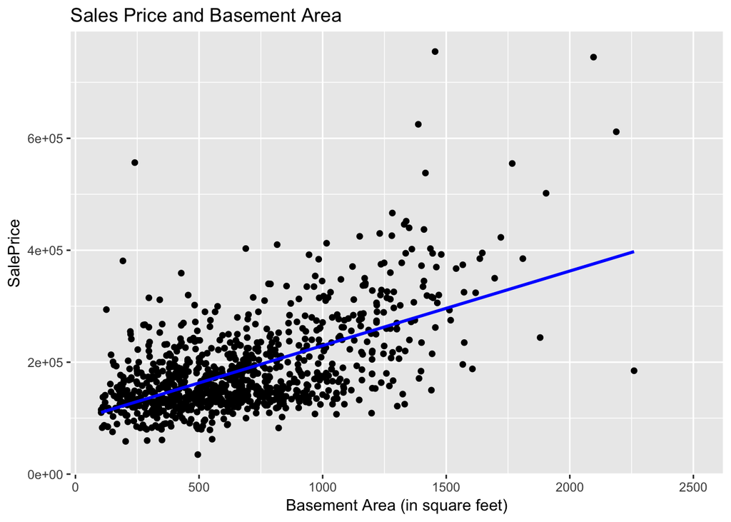

`Figure 2.6 summarizes the relationship of Sales Price and Basement Area of houses.`

#### **Neighborhood**

Neighborhood: Physical locations within Ames city limits

```
   Blmngtn  Bloomington Heights
   Blueste  Bluestem
   BrDale   Briardale
   BrkSide  Brookside
   ClearCr  Clear Creek
   CollgCr  College Creek
   Crawfor  Crawford
   Edwards  Edwards
   Gilbert  Gilbert
   IDOTRR   Iowa DOT and Rail Road
   MeadowV  Meadow Village
   Mitchel  Mitchell
   Names    North Ames
   NoRidge  Northridge
   NPkVill  Northpark Villa
   NridgHt  Northridge Heights
   NWAmes   Northwest Ames
   OldTown  Old Town
   SWISU    South & West of Iowa State University
   Sawyer   Sawyer
   SawyerW  Sawyer West
   Somerst  Somerset
   StoneBr  Stone Brook
   Timber   Timberland
   Veenker  Veenker
```

#### **YearBuilt**

YearBuilt: Original construction date.

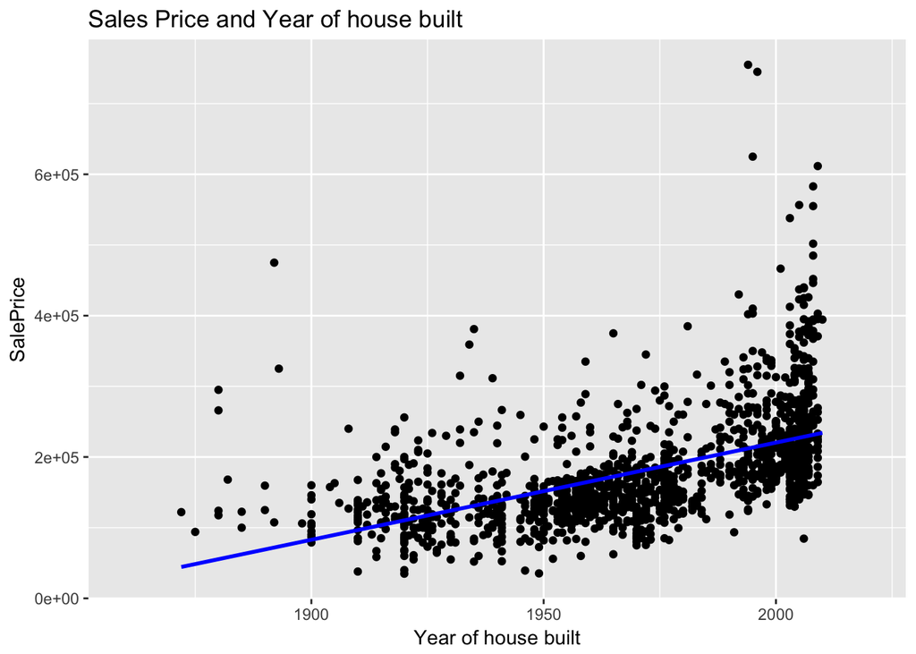

`Figure 2.7 summarizes the relationship of Sales Price and Year of house built.`

### 2.5 Inferential Models

We will investigate the validity of our hypothesis by using Ordinary Least Squares to generate three different models.

#### 2.5.1 Ordinary Least Squares

##### 2.5.2 Model 1.0

**Model 1.0: Car.Time.min**

```
## [1] "Model 1.0: Car.Time.min"
```

```
##
## Call:
## lm(formula = SalePrice ~ Car.Time.min + OverallQual + OverallCond +
##     GrLivArea, data = d_train_noNAs)
##
## Residuals:
##     Min      1Q  Median      3Q     Max
## -399052  -25375    -342   20852  280368
##
## Coefficients:
##                Estimate Std. Error t value Pr(>|t|)
## (Intercept)  -1.104e+05  1.102e+04 -10.023   <2e-16 ***
## Car.Time.min  3.353e+00  5.411e+02   0.006    0.995
## OverallQual   3.400e+04  1.198e+03  28.385   <2e-16 ***
## OverallCond  -8.115e+02  1.269e+03  -0.640    0.523
## GrLivArea     5.911e+01  3.201e+00  18.469   <2e-16 ***
## ---
## Signif. codes:  0 '***' 0.001 '**' 0.01 '*' 0.05 '.' 0.1 ' ' 1
##
## Residual standard error: 46380 on 1069 degrees of freedom
## Multiple R-squared:  0.7244, Adjusted R-squared:  0.7234
## F-statistic: 702.5 on 4 and 1069 DF,  p-value: < 2.2e-16
```

##### 2.5.3 Model 1.1

**Model 1.1: Walk.Time.min**

```
##
## Call:
## lm(formula = SalePrice ~ Walk.time.min + OverallQual + OverallCond +
##     GrLivArea, data = d_train_noNAs)
##
## Residuals:
##     Min      1Q  Median      3Q     Max
## -397783  -25848     148   21244  278739
##
## Coefficients:
##                 Estimate Std. Error t value Pr(>|t|)
## (Intercept)   -1.169e+05  1.022e+04 -11.441   <2e-16 ***
## Walk.time.min  1.390e+02  7.148e+01   1.945   0.0521 .
## OverallQual    3.391e+04  1.193e+03  28.435   <2e-16 ***
## OverallCond   -5.293e+02  1.252e+03  -0.423   0.6726
## GrLivArea      5.902e+01  3.195e+00  18.472   <2e-16 ***
## ---
## Signif. codes:  0 '***' 0.001 '**' 0.01 '*' 0.05 '.' 0.1 ' ' 1
##
## Residual standard error: 46300 on 1069 degrees of freedom
## Multiple R-squared:  0.7254, Adjusted R-squared:  0.7244
## F-statistic: 705.9 on 4 and 1069 DF,  p-value: < 2.2e-16
```

##### 2.5.4 Model 1.2

**Model 1.2: Bus.Time.min**

```
##
## Call:
## lm(formula = SalePrice ~ Bus.time.min + OverallQual + OverallCond +
##     GrLivArea, data = d_train_noNAs)
##
## Residuals:
##     Min      1Q  Median      3Q     Max
## -394798  -26218      89   21939  279488
##
## Coefficients:
##                Estimate Std. Error t value Pr(>|t|)
## (Intercept)  -116002.52    9982.53 -11.621   <2e-16 ***
## Bus.time.min     335.71     153.67   2.185   0.0291 *
## OverallQual    33453.23    1217.47  27.478   <2e-16 ***
## OverallCond     -518.42    1250.46  -0.415   0.6785
## GrLivArea         58.63       3.20  18.320   <2e-16 ***
## ---
## Signif. codes:  0 '***' 0.001 '**' 0.01 '*' 0.05 '.' 0.1 ' ' 1
##
## Residual standard error: 46280 on 1069 degrees of freedom
## Multiple R-squared:  0.7256, Adjusted R-squared:  0.7246
## F-statistic: 706.8 on 4 and 1069 DF,  p-value: < 2.2e-16
```

All our three naive models did not have good results, but when comparing the three models, Model 1.2 performed relatively better, with the highest R-square value (0.7256). We will use Model 1.2. in a more comprehensive model with all the variables in our dataset.

`Table 4: Comparing results from three models`

[output not shown]

##### 2.3.5 Model 2.0

**Model 2.0: Comprehensive model + Bus.Time.min**

```
##                  Estimate   Std. Error    t value  Pr(>|t|)
## (Intercept)  -358460.9992 1328337.8072 -0.2698568 0.7873458
## Bus.time.min     269.9592     547.9578  0.4926642 0.6223962
```

`Table 5: Results from using all variables in OLS`

| Variable | Model 2.0 - Full model + Bus.time.min |
| --- | --- |
| Estimate | 269.9592 |
| Std. Error | 547.9578 |
| t value | 0.4926642 |
| Pr(>abs(t) | 0.6223962 |
| Adj R Squared | 0.9417 |
| F-Statistic | 52.94 |

### 2.6 Lasso

The Lasso function will help us select the variables with the highest predictive power on Sales Price. It might also give us a clearer picture that will help us better assess our hypothesis.

Each curve corresponds to a variable. It shows the path of its coefficient against the ℓ1-norm of the whole coefficient vector at as λ varies. The axis above indicates the number of nonzero coefficients at the current λ, which is the effective degrees of freedom (df) for the lasso. Users may also wish to annotate the curves; this can be done by setting label = TRUE in the plot command.

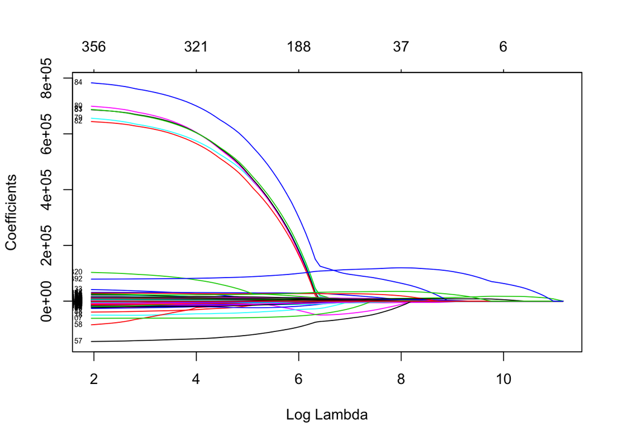

`Figure 3.1 : Lasso coefficients`

The cross-validation plot suggests that the model works best when it has approximately 11 predictors (when using lambda for the most regularized model such that error is within one standard error of the minimum.). Lasso helped to reduce the number of variables by over 87%. We can use cross-validation to extract coefficients that collectively minimize mean squared error.

It includes the cross-validation curve (red dotted line), and upper and lower standard deviation curves along the λ sequence (error bars). Two selected λ’s are indicated by the vertical dotted lines (see below).

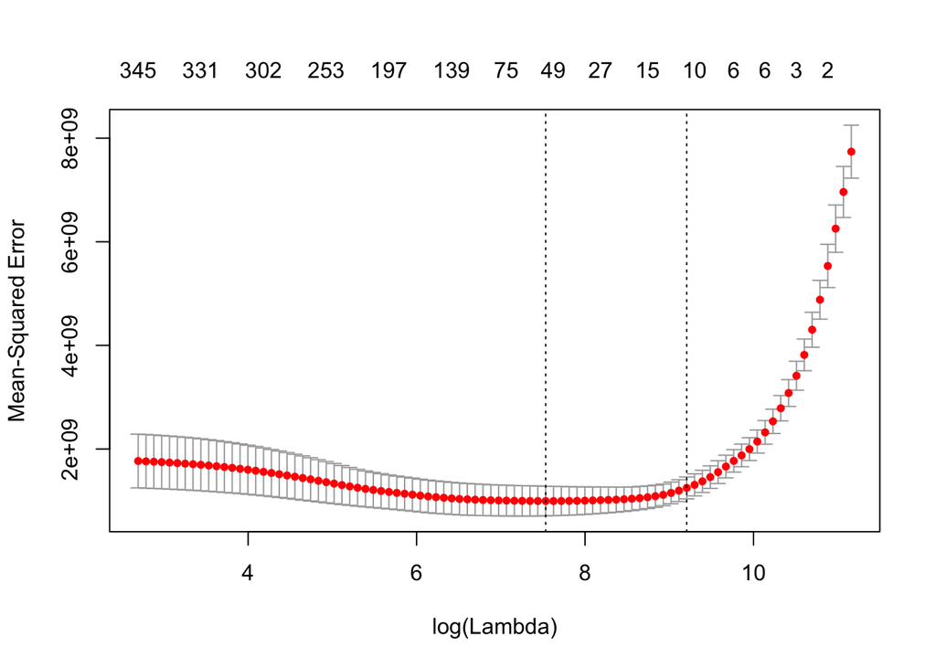

`Figure 3.2: Cross Validation for Lasso`

`Table 6: Lasso Coefficients`

| features | coefs |
| --- | --- |
| (Intercept) | -259608 |
| MSZoningRM | -152.3 |
| OverallQual | 14137 |
| YearBuilt | 92.26 |
| YearRemodAdd | 43.24 |
| TotalBsmtSF | 11.3 |
| X1stFlrSF | 4.649 |
| GrLivArea | 27.97 |
| Fireplaces | 1167 |
| GarageCars | 8251 |
| Mean.priceMedian | 19443 |
| Mean.priceHigher | 99254 |

### 2.7 Model 4 - Improved OLS

```
##  [1] MSZoningRM        OverallQual       YearBuilt
##  [4] YearRemodAdd      TotalBsmtSF       X1stFlrSF
##  [7] GrLivArea         Fireplaces        GarageCars
## [10] Mean.priceMedian  Mean.priceHigher
## 12 Levels: (Intercept) Fireplaces GarageCars ... YearRemodAdd
```

```
##
## Call:
## lm(formula = SalePrice ~ Bus.time.min + MSZoning + OverallQual +
##     YearBuilt + TotalBsmtSF + X1stFlrSF + GrLivArea + Fireplaces +
##     GarageCars + Mean.price, data = d_train_noNAs)
##
## Residuals:
##     Min      1Q  Median      3Q     Max
## -272464  -14380    1164   12392  282758
##
## Coefficients:
##                     Estimate Std. Error t value Pr(>|t|)
## (Intercept)       -4.282e+05  7.782e+04  -5.503 4.69e-08 ***
## Bus.time.min      -2.036e+02  9.930e+01  -2.051 0.040547 *
## MSZoningFV         3.681e+04  1.049e+04   3.508 0.000470 ***
## MSZoningRH         3.050e+04  1.229e+04   2.481 0.013242 *
## MSZoningRL         3.648e+04  9.603e+03   3.799 0.000154 ***
## MSZoningRM         2.395e+04  9.625e+03   2.488 0.012989 *
## OverallQual        9.374e+03  1.091e+03   8.592  < 2e-16 ***
## YearBuilt          2.117e+02  4.085e+01   5.183 2.62e-07 ***
## TotalBsmtSF        1.461e+01  3.888e+00   3.756 0.000182 ***
## X1stFlrSF         -3.982e-01  4.625e+00  -0.086 0.931411
## GrLivArea          3.182e+01  2.496e+00  12.751  < 2e-16 ***
## Fireplaces         8.141e+03  1.704e+03   4.778 2.02e-06 ***
## GarageCars         9.455e+03  1.597e+03   5.922 4.30e-09 ***
## Mean.priceMedian   4.482e+04  2.844e+03  15.758  < 2e-16 ***
## Mean.priceHigher   1.383e+05  4.432e+03  31.204  < 2e-16 ***
## ---
## Signif. codes:  0 '***' 0.001 '**' 0.01 '*' 0.05 '.' 0.1 ' ' 1
##
## Residual standard error: 29350 on 1059 degrees of freedom
## Multiple R-squared:  0.8907, Adjusted R-squared:  0.8892
## F-statistic: 616.1 on 14 and 1059 DF,  p-value: < 2.2e-16
```

##### Model 5

```
##
## Call:
## lm(formula = SalePrice ~ Bus.time.min + MSZoning + OverallQual +
##     YearBuilt + TotalBsmtSF + X1stFlrSF + GrLivArea + Fireplaces +
##     GarageCars + Mean.price, data = pref.data)
##
## Residuals:
##     Min      1Q  Median      3Q     Max
## -116169  -25437   -1080   20819  160867
##
## Coefficients:
##                    Estimate Std. Error t value Pr(>|t|)
## (Intercept)      -1.307e+06  4.473e+05  -2.922 0.003877 **
## Bus.time.min     -6.157e+02  2.916e+02  -2.112 0.035969 *
## MSZoningRL       -3.017e+03  1.165e+04  -0.259 0.795940
## MSZoningRM        7.563e+03  2.519e+04   0.300 0.764340
## OverallQual       1.626e+04  4.196e+03   3.877 0.000144 ***
## YearBuilt         6.081e+02  2.267e+02   2.683 0.007921 **
## TotalBsmtSF       4.978e+01  1.612e+01   3.088 0.002301 **
## X1stFlrSF         1.197e+01  1.728e+01   0.692 0.489466
## GrLivArea         7.528e+01  6.919e+00  10.879  < 2e-16 ***
## Fireplaces        2.052e+04  7.163e+03   2.865 0.004615 **
## GarageCars        2.905e+03  6.691e+03   0.434 0.664599
## Mean.priceHigher  4.124e+04  7.474e+03   5.517 1.07e-07 ***
## ---
## Signif. codes:  0 '***' 0.001 '**' 0.01 '*' 0.05 '.' 0.1 ' ' 1
##
## Residual standard error: 42690 on 198 degrees of freedom
## Multiple R-squared:  0.7427, Adjusted R-squared:  0.7284
## F-statistic: 51.96 on 11 and 198 DF,  p-value: < 2.2e-16
```

## 3. Predictive Model

In this section, we aim to find the most important variables that affect the Sales Price and build predictive models based on that. We will compare the effectiveness of different predictive models and choose the best model.

### 3.1 Variable Selection

#### 3.1.1 Correlation with SalePrice

We would like to see What numeric variables correlated with SalePrice.

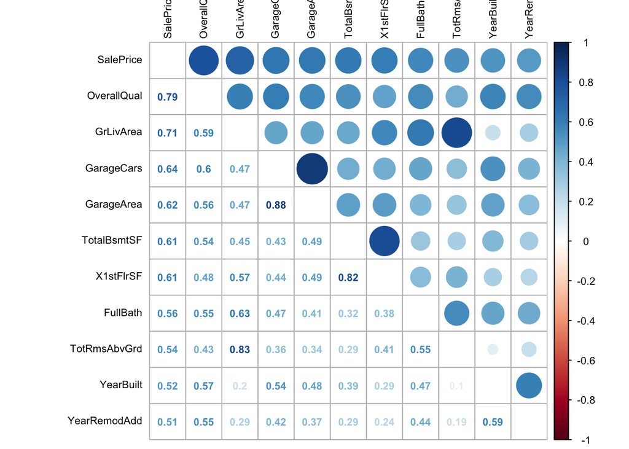

`Figure 4: Correlation Table of Sales Price and all numeric variables`

Since there are several paris of varibles are highly correlated to each other, we can simply drop one of them.Therefore, I chose to drop ‘TotalRmsAbvGrd’(vs GrLivArea); ‘GarageArea’(vs GarageCars); ‘TotalBsmtSF’ (vs X1stFkrSF); ‘YearRemodAdd’(vs YearBiult)

### 3.2 Random Forest

The correlation table above provides a good overview of the most important numeric variables and multicollinearity among those variables. Next, I want to get an overview of the most important variables including the categorical variables.

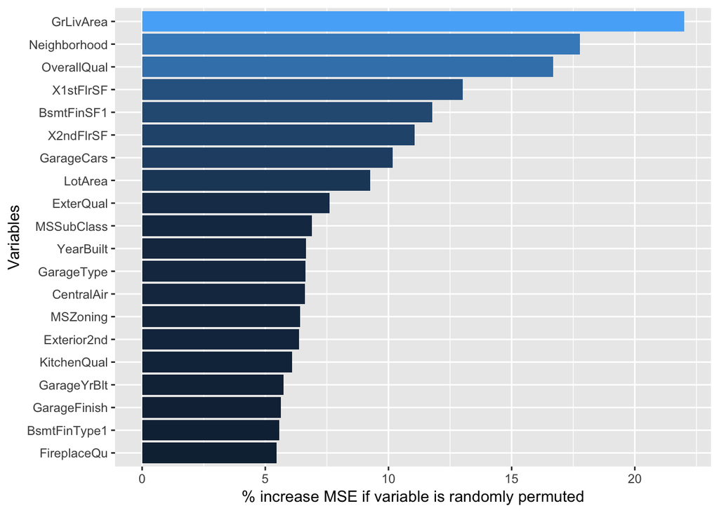

`Figure 5: Varaible selection by random forest`

### 3.3 Predictive Models

We pick variables that increase MSE if variable is randomly permuted greater than 10% (exclude two variables which are X1ndFlrSF and X2ndFlrSF which representing First/Second floor square feet, and are included in GrLivArea)。 Therefore, we choose to include total 5 variables: GarageCars+ BsmtFinSF1+ OverallQual + Neighborhood + GrLivArea in our models.

For model evaluation, since our class labels are not uniformly distributed, we decided to focus on four key metrics: 1) ‘Overall classification accuracy’ which is defined as the fraction of instances that are correctly classified; 2) ‘Precision’ which is defined as the fraction of correct predictions for a certain class; 3) ‘Recall’ which is the fraction of instances of a class that were correctly predicted; 4) ‘F1 score’ which is defined as the harmonic mean (or a weighted average) of precision and recall.

#### 3.3.1 Vector Generalized Linear Model

Train the Vector Generalized Linear Model and summarize the prediction results of the training set

```
##
## predictions Lower Median  Higher
##           1   730      46      0
##           2    39     177     19
##           3     1      11     69
```

```
## [1] 0.8937729
```

| precision | recall | f1 |
| --- | --- | --- |
| 0.9480519 | 0.9407216 | 0.9443726 |
| 0.7564103 | 0.7531915 | 0.7547974 |
| 0.7840909 | 0.8518519 | 0.8165680 |

#### 3.3.2 Linear Discriminant Analysis

Train the Linear Discriminant Analysis Model and summarize the prediction results of the training set

```
##      Lower           Median              Higher
##  Min.   :0.0000   Min.   :0.000002   Min.   :0.0000000
##  1st Qu.:0.2949   1st Qu.:0.005504   1st Qu.:0.0000006
##  Median :0.9413   Median :0.039428   Median :0.0000155
##  Mean   :0.6864   Mean   :0.229412   Mean   :0.0841964
##  3rd Qu.:0.9926   3rd Qu.:0.440473   3rd Qu.:0.0011525
##  Max.   :1.0000   Max.   :0.983326   Max.   :0.9999980
```

```
##          z_LDA_train
##           Lower Median  Higher
##   Lower     701      63      6
##   Median     47     160     27
##   Higher      1      28     59
```

```
## [1] 0.8424908
```

| precision | recall | f1 |
| --- | --- | --- |
| 0.9359146 | 0.9103896 | 0.9229756 |
| 0.6374502 | 0.6837607 | 0.6597938 |
| 0.6413043 | 0.6704545 | 0.6555556 |

Summarize the prediction results of the testing set

```
##      Lower           Median               Higher
##  Min.   :0.0000   Min.   :0.0000259   Min.   :0.0000000
##  1st Qu.:0.3607   1st Qu.:0.0045053   1st Qu.:0.0000005
##  Median :0.9508   Median :0.0339431   Median :0.0000153
##  Mean   :0.7015   Mean   :0.1863018   Mean   :0.1122139
##  3rd Qu.:0.9938   3rd Qu.:0.2683465   3rd Qu.:0.0010367
##  Max.   :1.0000   Max.   :0.9655164   Max.   :0.9999676
```

```
##          z_LDA_test
##           Lower Median  Higher
##   Lower     238      11      1
##   Median     14      43     17
##   Higher      0       3     22
```

```
## [1] 0.8681948
```

| precision | recall | f1 |
| --- | --- | --- |
| 0.9444444 | 0.9520000 | 0.9482072 |
| 0.7543860 | 0.5810811 | 0.6564885 |
| 0.5500000 | 0.8800000 | 0.6769231 |

#### 3.3.3 Support Vector Machine

Train the Support Vector Machine Model and summarize the prediction results of the training set

```
##          y_pred_train
##           Lower Median  Higher
##   Lower     764       6      0
##   Median     14     218      2
##   Higher      0       0     88
```

```
## [1] 0.9798535
```

| precision | recall | f1 |
| --- | --- | --- |
| 0.9820051 | 0.9922078 | 0.9870801 |
| 0.9732143 | 0.9316239 | 0.9519651 |
| 0.9777778 | 1.0000000 | 0.9887640 |

Summarize the prediction results of testing set

```
##          y_pred_test
##           Lower Median  Higher
##   Lower     244       6      0
##   Median     13      55      6
##   Higher      0       4     21
```

```
## [1] 0.9169054
```

| precision | recall | f1 |
| --- | --- | --- |
| 0.9494163 | 0.9760000 | 0.9625247 |
| 0.8461538 | 0.7432432 | 0.7913669 |
| 0.7777778 | 0.8400000 | 0.8076923 |

#### 3.3.4 Random Forest Model

Train the Random Forest Model and summarize the prediction results of the training set

### 3.4 Results

#### Linear Discriminant Analysis Model

The prediction accuracy of Linear Discriminant Analysis Model in training set is 0.8424908. The prediction accuracy of Linear Discriminant Analysis Model in the testing set is 0.8681948. For training set, as the Linear Discriminant Analysis classifier attempted to predict ‘Lower’ class most of the time, better performance in metrics for ‘Lower’ was achieved while the other two categories were much poorly predicted. For the testing set, Linear Discriminant Analysis Model best performed in ‘Lower’ category while poorly performed in two other categories. As consequence, it results in a poor overall prediction accuracy.

#### Support Vector Machine Model

The prediction accuracy of Support Vector Machine Model in training set is 0.9798535. The prediction accuracy of Support Vector Machine Model in the testing set is 0.9169054. For the testing set, Support Vector Machine Model best performed in ‘Lower’ category while poorly performed in two other categories. There was also a trade-off between ‘Median’ and ‘Higher’ groups as the recall for ‘Higher’ group is higher(0.84) but the precision(0.78) is poorer, just opposite to ‘Median’ which has higher precision but lower recall.

## 4. Conclusion

`Table 7: Recommended Neighboorhoods for the Client`

| Code | FullName | Car.Time.min | Walk.time.min | Bus.time.min | Avg Final Price | Overall Qual | Overall Cond |
| --- | --- | --- | --- | --- | --- | --- | --- |
| CollgCr | College Creek | 5 | 12 | 14 | $197,703.80 | 6.63 | 5.241611 |
| Crawfor | Crawford | 5 | 20 | 18 | $210,824.74 | 6.28 | 6.66 |

Lastly, we performed predictive analysis of the sales price of a house. By analysis, we found that there are five most important factors that affect the final sales price of a house: internally, all of the Overall Quality of the house; the above ground living area, the basement area and the garage capacity of the house affect the final sales price; externally, which neighbourhood the house in Ames, IA the house located in matters quite a lot on the final sales price. As for predictive model, we applied data into four different types of classification models (Vector Generalized Linear Model, Linear Discriminant Analysis Model, Suppoprt Vector Machine Model and Random Forest Models) and found out the support vector machine model gave the best predictive result in testing data (accuracy = 0.9169) among all.

Should the client choose to continue with the project the following next steps are essential to improve our results and provide further guidance in this important purchase:

1. Time Series Analysis on Pricing
2. Cluster Analysis on Neighborhood
3. Specific client data
4. Analyze city-wide plans and developments that could affect our models and forecasting.

## Annex

### Data Description

| Variable | Quantitative? | Class |
| --- | --- | --- |
| 1stFlrSF | Yes | int |
| 2ndFlrSF | Yes | int |
| 3SsnPorch | Yes | int |
| BedroomAbvGr | Yes | int |
| BsmtFinSF1 | Yes | int |
| BsmtFinSF2 | Yes | int |
| BsmtFullBath | Yes | int |
| BsmtHalfBath | Yes | int |
| BsmtUnfSF | Yes | int |
| EnclosedPorch | Yes | int |
| Fireplaces | Yes | int |
| FullBath | Yes | int |
| GarageArea | Yes | int |
| GarageCars | Yes | int |
| GarageYrBlt | Yes | int |
| GrLivArea | Yes | int |
| HalfBath | Yes | int |
| KitchenAbvGr | Yes | int |
| LotArea | Yes | int |
| LotFrontage | Yes | int |
| LowQualFinSF | Yes | int |
| MasVnrArea | Yes | int |
| MiscVal | Yes | int |
| MoSold | Yes | int |
| MSSubClass | Yes | int |
| OpenPorchSF | Yes | int |
| OverallCond | Yes | int |
| OverallQual | Yes | int |
| PoolArea | Yes | int |
| ScreenPorch | Yes | int |
| TotalBsmtSF | Yes | int |
| TotRmsAbvGrd | Yes | int |
| WoodDeckSF | Yes | int |
| YearBuilt | Yes | int |
| YearRemodAdd | Yes | int |
| YrSold. | Yes | int |
| Alley | No | Factor |
| BldgType | No | Factor |
| BsmtCond | No | Factor |
| BsmtExposure | No | Factor |
| BsmtFinType1 | No | Factor |
| BsmtFinType2 | No | Factor |
| BsmtQual | No | Factor |
| CentralAir | No | Factor |
| Condition1 | No | Factor |
| Condition2 | No | Factor |
| Electrical | No | Factor |
| ExterCond | No | Factor |
| Exterior1st | No | Factor |
| Exterior2nd | No | Factor |
| ExterQual | No | Factor |
| Fence | No | Factor |
| FireplaceQu | No | Factor |
| Foundation | No | Factor |
| Functional | No | Factor |
| GarageCond | No | Factor |
| GarageFinish | No | Factor |
| GarageQual | No | Factor |
| GarageType | No | Factor |
| Heating | No | Factor |
| HeatingQC | No | Factor |
| HouseStyle | No | Factor |
| KitchenQual | No | Factor |
| LandContour | No | Factor |
| LandSlope | No | Factor |
| LotConfig | No | Factor |
| LotShape | No | Factor |
| MasVnrType | No | Factor |
| MiscFeature | No | Factor |
| MSZoning | No | Factor |
| Neighborhood | No | Factor |
| PavedDrive | No | Factor |
| PoolQC | No | Factor |
| RoofMatl | No | Factor |
| RoofStyle | No | Factor |
| SaleCondition | No | Factor |
| SaleType | No | Factor |
| Street | No | Factor |
| Utilities. | No | Factor |

### Distance Variables

| Variable | Description |
| --- | --- |
| Neighborhood | The name of the neighborhood from the original data. |
| FullName | Full name of the neighborhood. |
| Lat/Log | The approximate latitude and longitude of the reference point for each neighborhood. |
| Car.miles | Average distance of suggested routes between the reference point and the ISU campus. |
| Car.Time.min | Average journey duration of suggested routes between the reference point and the ISU campus. |
| Walk.miles | Average distance of suggested routes between the reference point and the ISU campus. |
| Walk.time.min | Average journey duration of suggested routes between the reference point and the ISU campus. |
| Bus.time.min | Average journey duration of suggested routes between the reference point and the ISU campus. |

[^1]: https://www.kaggle.com/c/house-prices-advanced-regression-techniques
[^2]: https://datausa.io/profile/geo/ames-ia/